# ecoEd Champions 2018: Ecosystem Surveillance (AusPlots)

## "Understanding and using the ‘ausplotsR’ package and AusPlots data"

This document contains the “Ecosystem Surveillance (AusPlots): Understanding and using the ‘ausplotsR’ package and AusPlots data” tutorial for the ecoEd Champions Training 2018. In this tutorial we will explore the use of the package ‘ausplotsR’ & the ‘ausplots’ data that can be downloaded with this package.

`ausplotsR` is an R package for live extraction and preparation of TERN AusPlots ecosystem monitoring data. Through ausplotsR, users can: (1) directly obtain plot-based data on vegetation and soils across Australia, and (2) preprocess these data into structures that facilitate the visualisation and analysis of ausplots data. Data preprocessing includes the computation of species occurrence, vegetation cover, growth form, and basal area.

In this section of the workshop we will cover the following aspects:

### ACCESSING AND INSTALLING THE `ausplotsR` PACKAGE (plus its Dependencies)

The package `ausplotsR` can be installed directly from github using the ‘devtools’ package, which must have been previously installed. The GitHub site for the package contains the latest developments and information on `ausplotsR`; it can be found in [this link](https://github.com/GregGuerin/ausplotsR).

```r
## Install directly from github using the 'devtools' package
## Thus, 'devtools' must be previouly installed
#install.packages("devtools", repos="https://cloud.r-project.org/")
#library(devtools)
#install_github("GregGuerin/ausplotsR", build_vignettes = TRUE)

## Load the package
#library(ausplotsR)

## Obtaining Help and Initial Steps
#help(ausplotsR)
#browseVignettes(package="ausplotsR")
```

Perhaps you also need to install the other packages required for this section of the workshop. A list of Compresenhive R Archive Network (CRAN) mirror URLs can be found [here](https://cran.r-project.org/mirrors.html).

```r
## Select the repository (i.e. CRAN mirror URL)
#my.repos = "https://cloud.r-project.org/"
#my.repos = "https://cran.csiro.au/"

## Install other required libraries
#install.packages(c("ausplotsR", "vegan", "goeveg", "maps", "maptools", "mapdata", "sp",                        ggplot2", "gridExtra", "ggspatial", "dendextend"), repos=my.repos)
```

Before proceeding any further we load the other libraries that we will need for the workshop

```r
# Load packages
library(ausplotsR)  # If not loaded above
library(vegan)
library(goeveg)

library(maps)
library(maptools)
library(mapdata)
library(sp)
library(ggplot2)
library(gridExtra)
#library(ggspatial)

library(dendextend)
```

### OBTAIN & EXPLORE AusPlots DATA: `get_ausplots` function

This function extracts and compiles AusPlots data.

Up to 8 different types of data can be obtained by setting the corresponding arguments to TRUE/FALSE:

In addition AusPlot data can be subset via the `get_ausplots` function arguments in two other ways:

- `my.Plot_IDs`: Character vector with the plots IDs of specific AusPlots plots.
- `bounding_box`: Spatial filter for selecting AusPlots based on a rectangular box, in the format of e.g. c(xmin, xmax, ymin, ymax). AusPlots spatial data are are in longlat, thus x is the longitude and y is the latitude of the box/extent object (e.g., c(120, 140, -30, -10)).

The R object resulting from calling `get_ausplots` is a list of data frames containing the requested AusPlots data. The list includes a data frame for each type of data requested (i.e. up to 8 data frames: ‘site_info’, ‘structural_summaries’,…). These data frames are interrelated and they all have a common variable, `site_location_name`. In each data frame the columns correspond to the variables supplied for each type of data and the number of rows (directly or indirectly) depends on the sites retrieved (e.g. via `my.Plot_IDs` or `bounding_box`).

```r
# Example 1: All available data for 3 plots
# ==========================================

# Obtain the data ('site_info', 'veg.vouchers', and 'veg.PI' are retraived by default)
AP.data = get_ausplots( my.Plot_IDs=c("SATFLB0004", "QDAMGD0022", "NTASTU0002"),
                        structural_summaries=TRUE, basal.wedge=TRUE,
                                  soil_subsites=TRUE, soil_bulk_density=TRUE, soil_character=TRUE  )
```

```
## User-supplied Plot_IDs located.
```

```r
# Explore retrieved data
class(AP.data)
```

```
## [1] "list"
```

```r
summary(AP.data)
```

```
##               Length Class      Mode
## site.info     41     data.frame list
## struct.summ   13     data.frame list
## soil.subsites 10     data.frame list
## soil.bulk     13     data.frame list
## soil.char     32     data.frame list
## veg.basal     10     data.frame list
## veg.vouch     12     data.frame list
## veg.PI        13     data.frame list
```

```r
str(AP.data)
```

```
## List of 8
##  $ site.info    :'data.frame':   3 obs. of  41 variables:
##   ..$ site_location_name        : chr [1:3] "NTASTU0002" "QDAMGD0022" "SATFLB0004"
##   ..$ established_date          : chr [1:3] "2016-05-01T16:58:00" "2013-06-04T00:00:00" "2012-09-18T00:00:00"
##   ..$ description               : chr [1:3] "Maryfield Station, 7.6km north north west of homestead. 27.5km south east of Larrimah" "Mackunda Downs Station, 500m east of homestead.  26km west of Middleton." "Brachina Gorge Heysen Range Lower. 63km North North East of Adelaide"
##   ..$ bioregion_name            : chr [1:3] "STU" "MGD" "FLB"
##   ..$ landform_pattern          : chr [1:3] "PLA" "ALP" "MOU"
##   ..$ landform_element          : chr [1:3] "PLA" "PLA" "HSL"
##   ..$ site_slope                : chr [1:3] "0" "1" "18"
##   ..$ site_aspect               : chr [1:3] NA "180" "135"
##   ..$ comments                  : chr [1:3] "Plot is flat. Low mound ( Likely anthropogenic) made up of ironstone gravels at the north west corner. Minimal "| __truncated__ "Astrebla pectinata / Cenchrus ciliaris / Astrebla elymoides low open tussock grassland on alluvial plain adjoin"| __truncat…
##   ..$ outcrop_lithology         : chr [1:3] "NA" "NA" "NC"
##   ..$ other_outcrop_lithology   : chr [1:3] "NC" "NA" "NC"
##   ..$ plot_dimensions           : chr [1:3] NA "100m x 100m." NA
##   ..$ site_location_visit_id    : int [1:3] 58429 53501 53705
##   ..$ visit_start_date          : chr [1:3] "2016-05-01T16:58:00" "2013-05-18T09:34:00" "2012-09-18T00:00:00"
##   ..$ visit_end_date            : chr [1:3] "2016-05-01T16:58:00" "2013-05-18T09:34:00" "2012-09-18T00:00:00"
##   ..$ visit_notes               : chr [1:3] "Corymbia polycarpa and Corymbia terminalis combined for Basal area\r\n\r\nunknown substrate in point intercept "| __truncated__ "" NA
##   ..$ location_description      : chr [1:3] "Maryfield Station, 7.6km north north west of homestead. 27.5km south east of Larimah" "Mackunda Station, north of Middleton." "Brachina Gorge Heysen Range Lower. 63km North North East of Adelaide"
##   ..$ erosion_type              : chr [1:3] "n/a" "G" "NC"
##   ..$ erosion_abundance         : chr [1:3] "X" "2" "NC"
##   ..$ erosion_state             : chr [1:3] "n/a" "NC" "NC"
##   ..$ microrelief               : chr [1:3] "TM" "Z" "NC"
##   ..$ drainage_type             : int [1:3] 4 4 7
##   ..$ disturbance               : chr [1:3] "0" "1L" "NC"
##   ..$ climatic_condition        : chr [1:3] "DRY" "DRY" "Wet"
##   ..$ vegetation_condition      : chr [1:3] "AVG" "DRY" "Active vegetative growth"
##   ..$ observer_veg              : int [1:3] 1 3 16
##   ..$ observer_soil             : int [1:3] 2 2 1
##   ..$ described_by              : int [1:3] 1 3 16
##   ..$ pit_marker_easting        : int [1:3] 326265 529568 839490
##   ..$ pit_marker_northing       : int [1:3] 8256078 7526350 6528576
##   ..$ pit_marker_mga_zones      : int [1:3] 53 54 53
##   ..$ pit_marker_datum          : chr [1:3] "WGS84" "WGS84" "GDA94"
##   ..$ pit_marker_location_method: chr [1:3] NA "GPS" "GPS"
##   ..$ soil_observation_type     : chr [1:3] "P" "P" "P"
##   ..$ a_s_c                     : chr [1:3] NA "NC" NA
##   ..$ plot_is_100m_by_100m      : logi [1:3] TRUE TRUE TRUE
##   ..$ plot_is_aligned_to_grid   : logi [1:3] TRUE TRUE TRUE
##   ..$ plot_is_permanently_marked: logi [1:3] TRUE TRUE TRUE
```

[output cut: 98 more lines]

```
##   ..$ site_unique               : chr [1:149] "QDAMGD0022-53501" "QDAMGD0022-53501" "QDAMGD0022-53501" "QDAMGD0022-53501" ...
##  $ veg.PI       :'data.frame':   3217 obs. of  13 variables:
##   ..$ site_location_name     : chr [1:3217] "QDAMGD0022" "QDAMGD0022" "QDAMGD0022" "QDAMGD0022" ...
##   ..$ site_location_visit_id : int [1:3217] 53501 53501 53501 53501 53501 53501 53501 53501 53501 53501 ...
##   ..$ transect               : Factor w/ 15 levels "E2-W2","E4-W4",..: 13 13 13 13 13 13 1 1 1 1 ...
##   ..$ point_number           : int [1:3217] 27 96 97 98 99 100 0 1 3 4 ...
##   ..$ veg_barcode            : chr [1:3217] NA NA NA NA ...
##   ..$ herbarium_determination: chr [1:3217] NA NA NA NA ...
##   ..$ substrate              : chr [1:3217] "Bare" "Bare" "Litter" "Bare" ...
##   ..$ in_canopy_sky          : logi [1:3217] NA NA NA NA NA FALSE ...
##   ..$ dead                   : logi [1:3217] NA NA NA NA NA FALSE ...
##   ..$ growth_form            : chr [1:3217] NA NA NA NA ...
##   ..$ height                 : num [1:3217] NA NA NA NA NA 0.2 NA NA NA 0.1 ...
##   ..$ hits_unique            : chr [1:3217] "W1-E1 27" "W1-E1 96" "W1-E1 97" "W1-E1 98" ...
##   ..$ site_unique            : chr [1:3217] "QDAMGD0022-53501" "QDAMGD0022-53501" "QDAMGD0022-53501" "QDAMGD0022-53501" ...
```

```r
# Example 2: Default data for a particular Geographic Extent
# ==========================================================

# 'site_info', 'veg.vouchers', and 'veg.PI' data retrived for Brisbane (27.4698S, 153.0251E) and its sourrounding area
AP.data = get_ausplots(bounding_box=c(152.5, 153.5, -28, -27))

# Explore retrieved data
#class(AP.data)   # As in Example 1 (can run uncommented if curious)
summary(AP.data)
```

```
##           Length Class      Mode
## site.info 41     data.frame list
## veg.vouch 12     data.frame list
## veg.PI    13     data.frame list
```

```r
#str(AP.data)   # Similar to Example 1 (can run uncommented if curious)


# Example 3: 'site_info', 'veg.PI', and 'basal.wedge' data for al sites
# =====================================================================

# Retreive data
start.time = Sys.time()
AP.data = get_ausplots(veg.vouchers=FALSE, basal.wedge=TRUE)
end.time = Sys.time()
end.time - start.time
```

```
## Time difference of 59.50418 secs
```

```r
# Explore
#class(AP.data)   # As in Example 1 (can run uncommented if curious)
summary(AP.data)
```

```
##           Length Class      Mode
## site.info 41     data.frame list
## veg.basal 10     data.frame list
## veg.PI    13     data.frame list
```

```r
#str(AP.data)   # Similar to Example 1 (can run uncommented if curious)

# Explore 'site_info' data
dim(AP.data$site.info)
```

```
## [1] 607  41
```

```r
names(AP.data$site.info)
```

```
##  [1] "site_location_name"         "established_date"
##  [3] "description"                "bioregion_name"
##  [5] "landform_pattern"           "landform_element"
##  [7] "site_slope"                 "site_aspect"
##  [9] "comments"                   "outcrop_lithology"
## [11] "other_outcrop_lithology"    "plot_dimensions"
## [13] "site_location_visit_id"     "visit_start_date"
## [15] "visit_end_date"             "visit_notes"
## [17] "location_description"       "erosion_type"
## [19] "erosion_abundance"          "erosion_state"
## [21] "microrelief"                "drainage_type"
## [23] "disturbance"                "climatic_condition"
## [25] "vegetation_condition"       "observer_veg"
## [27] "observer_soil"              "described_by"
## [29] "pit_marker_easting"         "pit_marker_northing"
## [31] "pit_marker_mga_zones"       "pit_marker_datum"
## [33] "pit_marker_location_method" "soil_observation_type"
## [35] "a_s_c"                      "plot_is_100m_by_100m"
## [37] "plot_is_aligned_to_grid"    "plot_is_permanently_marked"
## [39] "latitude"                   "longitude"
## [41] "point"
```

```r
head(AP.data$site.info)
```

```
##   site_location_name    established_date
## 1         WAANUL0003 2014-07-01T15:18:42
## 2         NTAFIN0007 2011-10-12T00:00:00
## 3         SAASTP0003 2012-06-29T00:00:00
## 4         WAAHAM0006 2014-06-28T17:00:42
## 5         QDASSD0015 2014-05-08T00:00:00
## 6         QDASSD0001 2014-04-30T00:00:00
##                                                                                                        description
## 1         Plumridge Lakes Nature Reserve. About 178kms west south west  of Tjuntjuntjara in Great Victoria Desert.
## 2                Calcareous rise north of Waterhouse Range, Owen Springs Reserve. 52km South west of Alice Springs
## 3 Witjira National Park. West of Blood Creek Bore. 184km South East of Kulgera. Plot approx.. 100m north of track.
## 4                              About 28kms south east of Cocklebiddy and 5kms north west of Eyre Bird Observatory.
## 5                                                         Cravens Peak Reserve. 56km north west of Carlo homestead
## 6                                                                     Ethabuka Station. 10.7 km north of homestead
##   bioregion_name landform_pattern landform_element site_slope site_aspect
```

[output cut: 83 more lines]

```r
# Explore 'veg_PI' data
dim(AP.data$veg.PI)
```

```
## [1] 660321     13
```

```r
names(AP.data$veg.PI)
```

```
##  [1] "site_location_name"      "site_location_visit_id"
##  [3] "transect"                "point_number"
##  [5] "veg_barcode"             "herbarium_determination"
##  [7] "substrate"               "in_canopy_sky"
##  [9] "dead"                    "growth_form"
## [11] "height"                  "hits_unique"
## [13] "site_unique"
```

```r
head(AP.data$veg.PI)
```

```
##   site_location_name site_location_visit_id transect point_number
## 1         VCAAUA0001                  58565    W1-E1            0
## 2         VCAAUA0001                  58565    W1-E1            1
## 3         VCAAUA0001                  58565    W1-E1            2
## 4         VCAAUA0001                  58565    W1-E1            2
## 5         VCAAUA0001                  58565    W1-E1            3
## 6         VCAAUA0001                  58565    W1-E1            4
##   veg_barcode                      herbarium_determination substrate
## 1   VCA005003 Asterolasia trymalioides subsp. trymalioides    Litter
## 2   VCA005079                       Celmisia pugioniformis    Litter
## 3   VCA005089                                  Poa hiemata    Litter
## 4   VCA005035       Leptorhynchos squamatus subsp. alpinus    Litter
## 5   VCA005089                                  Poa hiemata    Litter
## 6   VCA005079                       Celmisia pugioniformis    Litter
##   in_canopy_sky  dead   growth_form height hits_unique      site_unique
## 1         FALSE FALSE   Heath-shrub   0.05     W1-E1 0 VCAAUA0001-58565
## 2         FALSE FALSE          Forb   0.01     W1-E1 1 VCAAUA0001-58565
## 3         FALSE FALSE Tussock grass   0.05     W1-E1 2 VCAAUA0001-58565
## 4         FALSE FALSE          Forb   0.03     W1-E1 2 VCAAUA0001-58565
## 5         FALSE FALSE Tussock grass   0.03     W1-E1 3 VCAAUA0001-58565
## 6         FALSE FALSE          Forb   0.01     W1-E1 4 VCAAUA0001-58565
```

### MANIPULATING AusPlots DATA

The retrieved data by the function ‘get_ausplots’ can be manipulated as any other R data. However, the ‘deep’ structure of the data and interrelation of the data frames (via the common `site_loation_name` variable) can make manipulating the data a bit more daunting.

As an example, we will focus on the sites in the 5 most sampled Bioregions. We will first identify which are these regions, and then subset the sites in these regions.

```r
#----------------------------------------------------------------------------------------
# Find the 5 most 'sampled' Bioregions
#----------------------------------------------------------------------------------------

# Create a derived Bioregions Factor Variable in the 'site.info' DF
AP.data$site.info$bioregion.f = factor(AP.data$site.info$bioregion_name)
#names(AP.data$site.info)

# Display the Bioregions number of visits (from most visited to least visited)
sort(summary(AP.data$site.info$bioregion.f), decreasing=TRUE)
```

```
## MDD SSD GFU STP PIL FLB MGD GUP BHC COO RIV MAC FIN NUL AUA CHC SYB EIU
##  51  48  41  38  35  34  34  33  32  32  32  28  18  13  12  10   9   7
## MUL BRT HAM MUR STU GVD AVW KAN SWA VIB ARP BBS CEK DAC DMR EYB GAW GES
##   7   6   6   6   6   5   4   4   4   4   3   3   3   3   3   3   3   3
## JAF LSD MAL PCK COP GAS MII DAB DAL ESP GSD NAN NSS
##   3   3   3   3   2   2   2   1   1   1   1   1   1
```

```r
# Get the Names of the 5 most visited Bioregions
Bioregs.Top5.s = names(sort(summary(AP.data$site.info$bioregion.f), decreasing=TRUE)[1:5])
Bioregs.Top5.s
```

```
## [1] "MDD" "SSD" "GFU" "STP" "PIL"
```

```r
#----------------------------------------------------------------------------------------
# Subset data for the 5 most 'visited/sampled' Bioregions
#----------------------------------------------------------------------------------------

summary(AP.data)
```

```
##           Length Class      Mode
## site.info 42     data.frame list
## veg.basal 10     data.frame list
## veg.PI    13     data.frame list
```

```r
# Subset the 5 most sampled Bioregions in the 'site.info' data frame
# ==================================================================
dim(AP.data$site.info)
```

```
## [1] 607  42
```

```r
AP.BioregTop5.l = AP.data
AP.BioregTop5.l$site.info = AP.BioregTop5.l$site.info[AP.BioregTop5.l$site.info$bioregion_name %in% Bioregs.Top5.s, ]
dim(AP.BioregTop5.l$site.info)
```

```
## [1] 213  42
```

```r
# Drop unused levels in the bioregion.f factor (i.e. the levels corresponding to other
# bioregions are dropped).
levels(AP.BioregTop5.l$site.info$bioregion.f)
```

```
##  [1] "ARP" "AUA" "AVW" "BBS" "BHC" "BRT" "CEK" "CHC" "COO" "COP" "DAB"
## [12] "DAC" "DAL" "DMR" "EIU" "ESP" "EYB" "FIN" "FLB" "GAS" "GAW" "GES"
## [23] "GFU" "GSD" "GUP" "GVD" "HAM" "JAF" "KAN" "LSD" "MAC" "MAL" "MDD"
## [34] "MGD" "MII" "MUL" "MUR" "NAN" "NSS" "NUL" "PCK" "PIL" "RIV" "SSD"
## [45] "STP" "STU" "SWA" "SYB" "VIB"
```

```r
AP.BioregTop5.l$site.info$bioregion.f = droplevels(AP.BioregTop5.l$site.info$bioregion.f)
levels(AP.BioregTop5.l$site.info$bioregion.f)
```

```
## [1] "GFU" "MDD" "PIL" "SSD" "STP"
```

```r
# Subset the 5 most sampled Bioregions in the 'veg.PI' data frame
# ===============================================================
dim(AP.BioregTop5.l$veg.PI)
```

```
## [1] 660321     13
```

```r
AP.BioregTop5.l$veg.PI = AP.BioregTop5.l$veg.PI[AP.BioregTop5.l$veg.PI$site_location_name %in% AP.BioregTop5.l$site.info$site_location_name, ]
dim(AP.BioregTop5.l$veg.PI)
```

```
## [1] 224160     13
```

```r
# Subset the 5 most sampled Bioregions in the 'veg.basal' data frame
# ==================================================================
dim(AP.BioregTop5.l$veg.basal)
```

```
## [1] 7093   10
```

```r
AP.BioregTop5.l$veg.basal = AP.BioregTop5.l$veg.basal[AP.BioregTop5.l$veg.basal$site_location_name %in% AP.BioregTop5.l$site.info$site_location_name, ]
dim(AP.BioregTop5.l$veg.basal)
```

```
## [1] 1999   10
```

### MAP THE SITES

Next we visualise the sites on a map of Australia. First we graph all the Sites curently in AusPlots and then the Sites in the 5 most sampled bioregions. To do so we first obtain the map from the `maps` package and convert it to `SpatialPolygons`. Then we plot the Sites on the SpatialPolygon object for the map of Australia using functions in the `ggplot2` package. To differenciate among bioregions, sites are represented by different shapes and colours in the first graph, and by dots of different colours in the second one.

```r
#----------------------------------------------------------------------------------------
# Get and Prepare a Map of Australia
#----------------------------------------------------------------------------------------

# Maps in the package 'maps' are projected in longlat by default
aus = map("worldHires", "Australia", fill=TRUE, xlim=c(110,160),ylim=c(-45,-5), mar=c(0,0,0,0), plot=FALSE)

# Convert map data to SpatialPolygons
#aus.sp = map2SpatialPolygons(aus, IDs=aus$names, proj4string=CRS("+proj=longlat"))
CRS("+init=epsg:4326") # More info (i.e. provides a datum)
```

```
## CRS arguments:
##  +init=epsg:4326 +proj=longlat +datum=WGS84 +no_defs +ellps=WGS84
## +towgs84=0,0,0
```

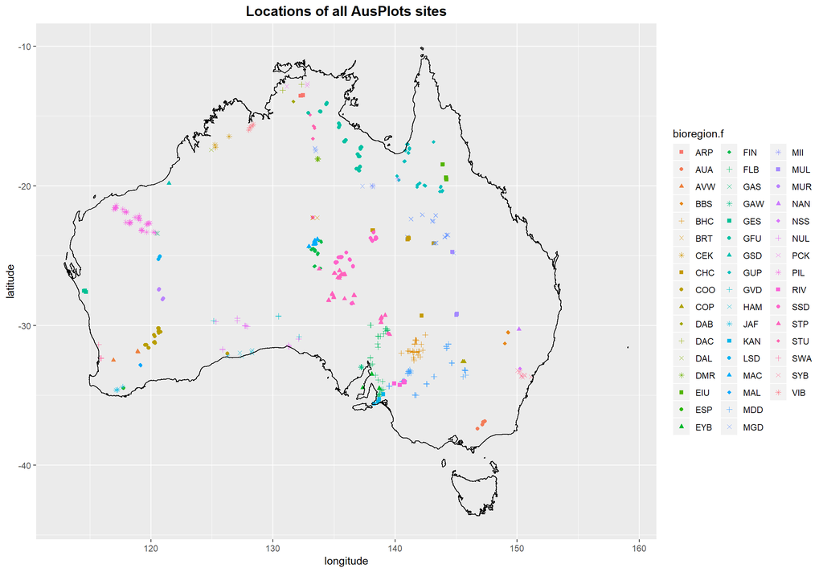

```r
aus.sp = map2SpatialPolygons(aus, IDs=aus$names, proj4string=CRS("+init=epsg:4326"))


#----------------------------------------------------------------------------------------
# Plot All AusPlots Sites on a Map of Australia
#----------------------------------------------------------------------------------------
ggplot( data=AP.data$site.info,
             aes(x = longitude, y = latitude, group=bioregion.f), alpha =0.5) +
geom_point(aes(colour=bioregion.f, fill=bioregion.f, shape=bioregion.f), size=1.5) +
scale_shape_manual(values=rep(c(15:18,3:4,8),7)) +  # Cycle through Symbol Types
ggtitle("Locations of all AusPlots sites") +
theme(plot.title = element_text(hjust = 0.5, face="bold", size=14)) +
geom_polygon(data=fortify(aus.sp), aes(x=long, y=lat, group=group), col="black", fill=NA)
```

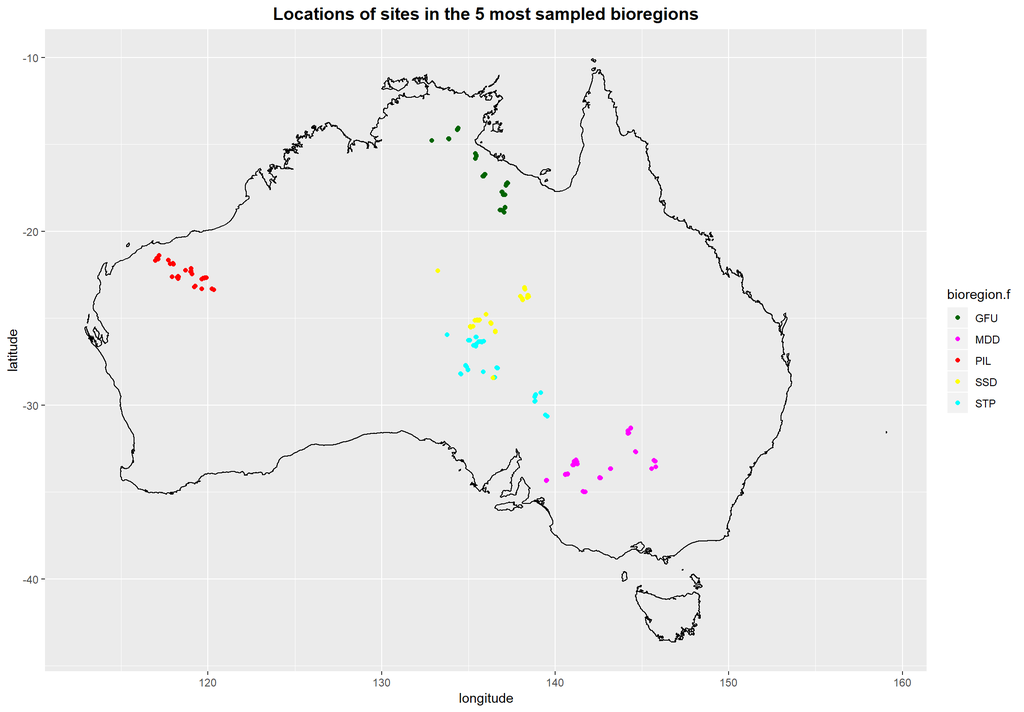

```r
#----------------------------------------------------------------------------------------
# Plot AusPlots sites in the 5 Bioregions on Map of Australia
#----------------------------------------------------------------------------------------
ggplot(data=AP.BioregTop5.l$site.info, aes(x = longitude, y = latitude, colour=bioregion.f, fill=bioregion.f), alpha =0.5) +
geom_point(pch=21, size=1.5) + scale_colour_manual(values = c("darkgreen", "magenta", "red", "yellow", "cyan")) +
scale_fill_manual(values = c("darkgreen", "magenta", "red", "yellow", "cyan")) +
ggtitle("Locations of sites in the 5 most sampled bioregions") +
theme(plot.title = element_text(hjust = 0.5, face="bold", size=14)) +
geom_polygon(data=fortify(aus.sp), aes(x=long, y=lat, group=group), col="black", fill=NA)
```

### SPECIES-LEVEL DATA: `species_table` function and species occurence matrices

#### First step: Create a species occurence matrix

The first step to work with species-level AusPlots data is to create a species occurrence matrix. The `species_table` function in the `ausplotsR` package can be used to effortlessly create this type of matrix. This function takes a data frame of individual raw point intercept hits (i.e. a `veg.PI` data frame) generated using the `get_ausplots` function and returns a ‘species against sites’ matrix. Four metrics can be selected to score species occurrence:

- *Presence/Absence* (argument `m_kind = PA`).
- *Percent Cover*: Based on total frequency of hits. This is the most commonly used metric (argument `m_kind = percent_cover`).
- *Frequency*: Based on proportional frequencies of presence on the 10 individual transects within a plot (argument `m_kind = freq`). It can be a measure of importance for low cover species.
- *IVI*: A combination of cover and frequency (argument `m_kind = IVI`).

If Percent Cover or IVI are used two types of cover type can be selected:

- *Projected Foliage Cover* (*PFC*):Hits scored as ‘in canopy sky’ are removed (argument `cover_type = PFC`).
- *Opaque Canopy Cover* (*OCC*): Hits scored as ‘in canopy sky’ are retained (argument `cover_type = OCC`).

```r
# Use function 'species_table' in 'ausplotsR' package to create an Abundance per Site Table
# =========================================================================================
SppBYSites.BioregTop5 = species_table(AP.BioregTop5.l$veg.PI, m_kind="percent_cover",                                            cover_type="PFC")
class(SppBYSites.BioregTop5)
```

```
## [1] "data.frame"
```

```r
dim(SppBYSites.BioregTop5) # Number of rows and columns in the matrix: 574 Sites x 3024 Spp
```

```
## [1]  209 1091
```

```r
SppBYSites.BioregTop5[1:5, 1:5]
```

```
##                  Abutilon.fraseri Abutilon.halophilum Abutilon.otocarpum
## NSAMDD0001-56965                0                   0                  0
## NSAMDD0002-56952                0                   0                  0
## NSAMDD0003-56968                0                   0                  0
## NSAMDD0004-56953                0                   0                  0
## NSAMDD0005-56969                0                   0                  0
##                  Abutilon.oxycarpum Abutilon.sp.
## NSAMDD0001-56965                  0            0
## NSAMDD0002-56952                  0            0
## NSAMDD0003-56968                  0            0
## NSAMDD0004-56953                  0            0
## NSAMDD0005-56969                  0            0
```

```r
# Enrich Table with: Site_Location, Bioregion, Latitude, and Longitude
# ====================================================================

# Create a site_visit variable in original dataset to relate both datasets
# -------------------------------------------------------------------------
AP.BioregTop5.l$site.info$Plot =  paste(AP.BioregTop5.l$site.info$site_location_name,
                                        AP.BioregTop5.l$site.info$site_location_visit_id, sep="-")
SppBYSites.BioregTop5$Plot = rownames(SppBYSites.BioregTop5)

# Both DF have differente number of rows!
dim(SppBYSites.BioregTop5)
```

```
## [1]  209 1092
```

```r
dim(AP.BioregTop5.l$site.info)
```

```
## [1] 213  43
```

```r
# Enrich with: Bioregion, Latitude, and Longitude
# -----------------------------------------------
SppBYSites.BioregTop5  = merge(SppBYSites.BioregTop5, AP.BioregTop5.l$site.info,                                          by="Plot")[,c(names(SppBYSites.BioregTop5),
                                          "bioregion.f", "longitude", "latitude")]
SppBYSites.BioregTop5 = na.omit(SppBYSites.BioregTop5)
#head(SppBYSites.BioregTop5)
#summary(SppBYSites.BioregTop5)
head(names(SppBYSites.BioregTop5))
```

```
## [1] "Abutilon.fraseri"    "Abutilon.halophilum" "Abutilon.otocarpum"
## [4] "Abutilon.oxycarpum"  "Abutilon.sp."        "Acacia.adoxa"
```

#### Species Abundance

In AusPlots data percent cover is used as a measure of abundance. In this section, we will examine percent cover by:

- Site visit and species: That is, all cells in the ‘Species by Sites’ table.
- Species: By computing the column totals in the ‘Species by Sites’ table.

##### Percent Cover (Abundance) by Site Visit x Species

```r
# Minimum and Maximum Site Visit x Species Abundance values
# ---------------------------------------------------------
# '-4' because we added 4 new columns (Plot, bioregion.f, longitude, and latitude)##
range(SppBYSites.BioregTop5[,1: (dim(SppBYSites.BioregTop5)[2]-4)])
```

```
## [1]  0.00000 81.18812
```

```r
# Plot Highest  Site Visit x Species Abundance values
# ---------------------------------------------------
Abundance = unlist(SppBYSites.BioregTop5[,1: (dim(SppBYSites.BioregTop5)[2]-4)])
head(Abundance)
```

```
## Abutilon.fraseri1 Abutilon.fraseri2 Abutilon.fraseri3 Abutilon.fraseri4
##                 0                 0                 0                 0
## Abutilon.fraseri5 Abutilon.fraseri6
##                 0                 0
```

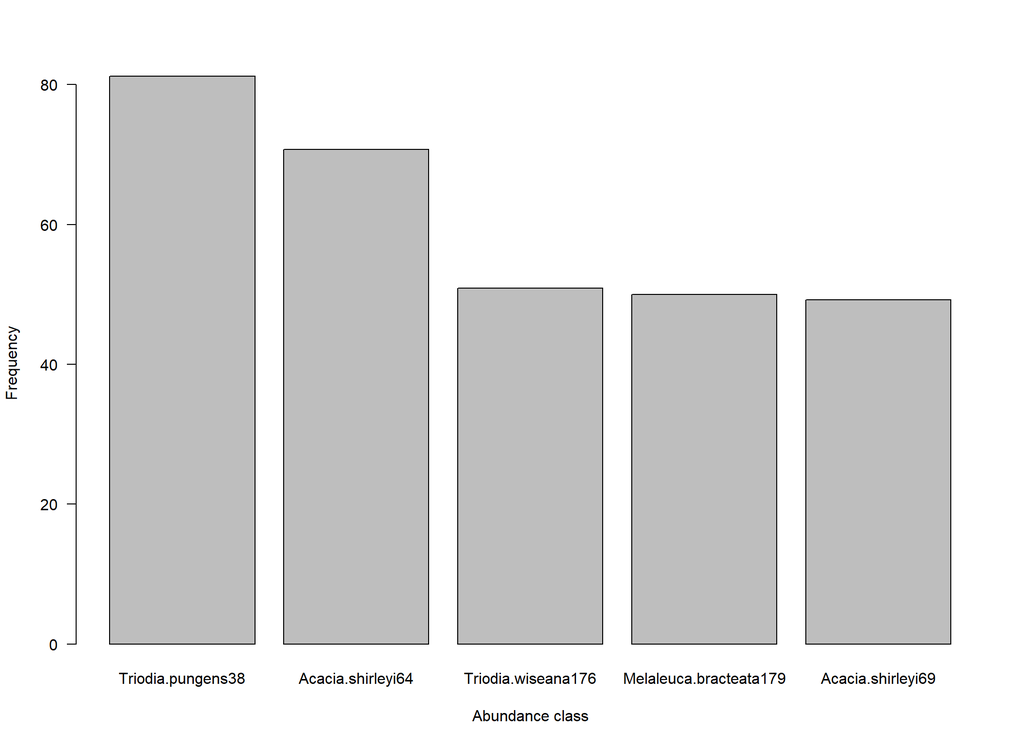

```r
#length(Abundance)
#dim(SppBYSites.BioregTop5)

# Plot the 5 Site Visits x Species combination with the Highest Abundances
par(mfrow=c(1,1))
barplot(sort(Abundance, decreasing=TRUE)[1:5], las=1, xlab="Abundance class", ylab="Frequency")
```

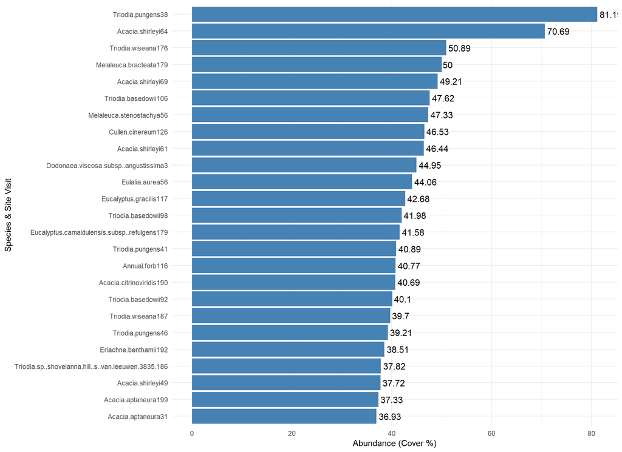

```r
# ggplot2 graph to make it look nicer. Now we plot the 25 species-site visit covers with horizontal bars
temp.labs = names(sort(Abundance, decreasing=TRUE))
temp.Abundances = sort(Abundance, decreasing=TRUE)
temp.df = data.frame(temp.Abundances, temp.labs)
# Order factor levels so that bars are sorted by Abundance in the plot. Otherwise they would plotted in alphabetical order
# 'rev' to plot bars in decreasing order (i.e. larger bar at top; otherwise larger bar at bottom)
temp.df$temp.labs = factor(temp.df$temp.labs, levels=rev(temp.df$temp.labs))
ggplot(data=temp.df[1:25,], aes(x=temp.labs, y=temp.Abundances)) +
geom_bar(stat="identity", fill="steelblue") +
geom_text(aes(label=round(temp.Abundances,2)), hjust=-0.1, size=4)+
labs(x="Species & Site Visit", y="Abundance (Cover %)") +
theme_minimal() + coord_flip()
```

```r
# Cleaning up
rm(list=ls(pattern="temp."))
```

##### Abundance (Cover %) by Species

Now we compute the percent cover of all species across the sites in the 5 most sampled bioregions. Then we find and plot on a map of Australia the 4 most Abundant species in the 5 regions (across all regions pooled together).

```r
# Compute Species Total Abundance (Cover %)
# -----------------------------------------
TotAbundances.BioregTop5 = colSums(SppBYSites.BioregTop5[,1:(dim(SppBYSites.BioregTop5)[2]-4)])
head(TotAbundances.BioregTop5)
```

```
##    Abutilon.fraseri Abutilon.halophilum  Abutilon.otocarpum
##           0.2970297           1.2871287           2.5757352
##  Abutilon.oxycarpum        Abutilon.sp.        Acacia.adoxa
##           0.3960396           0.5944519           0.4950495
```

```r
# Species with Highest Total Abundance
# ------------------------------------
# Species with Highest Total Abundance
max(TotAbundances.BioregTop5)
```

```
## [1] 366.8182
```

```r
which.max(TotAbundances.BioregTop5)
```

```
## Triodia.basedowii
##              1033
```

```r
# Species with Top 4 Highest Abundances
TotAbundances4Highest.indices =
     which(TotAbundances.BioregTop5 >= sort(TotAbundances.BioregTop5, decreasing=T)[4],               arr.ind=T)
sort(TotAbundances.BioregTop5[TotAbundances4Highest.indices], decreasing=TRUE)
```

```
## Triodia.basedowii     Eulalia.aurea   Triodia.pungens Triodia.bitextura
##          366.8182          310.1988          307.8218          283.4677
```

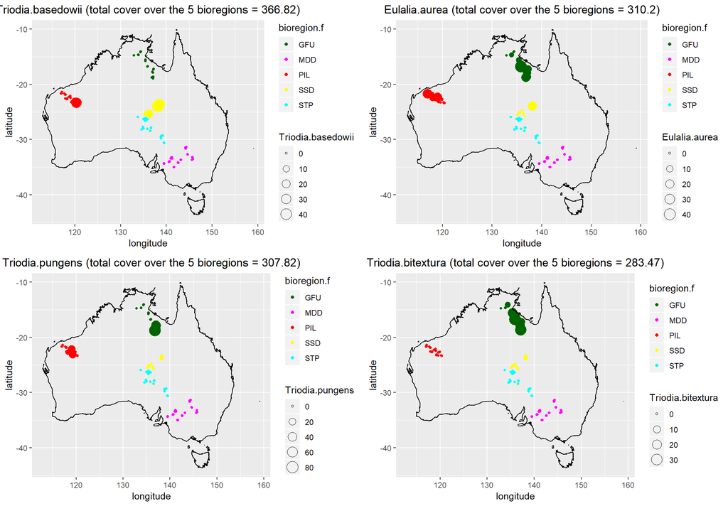

```r
# Plot 4 Species with Highest Cover in the 5 Most Sampled Bioregions
# ------------------------------------------------------------------

# Most Abundant Species
spp = names(sort(TotAbundances.BioregTop5[TotAbundances4Highest.indices],                                   decreasing=TRUE))[1]
plot.title =  paste(spp, " (total cover over the 5 bioregions = ",
                    round(sort(TotAbundances.BioregTop5[TotAbundances4Highest.indices],                                   decreasing=TRUE)[1],2) , ")", sep="")
TotAbundance.spp1 =
ggplot(data=SppBYSites.BioregTop5, aes(x=longitude, y=latitude, colour=bioregion.f, fill=bioregion.f), alpha =0.5) +
geom_point(aes_string(size=spp), pch=21) +
scale_colour_manual(values = c("darkgreen", "magenta", "red", "yellow", "cyan")) +
scale_fill_manual(values = c("darkgreen", "magenta", "red", "yellow", "cyan")) +
ggtitle(plot.title) + theme(plot.title = element_text(hjust = 0.5)) +
geom_polygon(data=fortify(aus.sp), aes(x=long, y=lat, group=group), col="black", fill=NA)

# 2nd Most Abundant Species
spp = names(sort(TotAbundances.BioregTop5[TotAbundances4Highest.indices],                                   decreasing=TRUE))[2]
plot.title =  paste(spp, " (total cover over the 5 bioregions = ",
                    round(sort(TotAbundances.BioregTop5[TotAbundances4Highest.indices],                              decreasing=TRUE)[2],2) , ")", sep="")
TotAbundance.spp2 =
ggplot(data=SppBYSites.BioregTop5, aes(x=longitude, y=latitude, colour=bioregion.f, fill=bioregion.f), alpha =0.5) +
geom_point(aes_string(size=spp), pch=21) +
scale_colour_manual(values = c("darkgreen", "magenta", "red", "yellow", "cyan")) +
scale_fill_manual(values = c("darkgreen", "magenta", "red", "yellow", "cyan")) +
ggtitle(plot.title) + theme(plot.title = element_text(hjust = 0.5)) +
geom_polygon(data=fortify(aus.sp), aes(x=long, y=lat, group=group), col="black", fill=NA)

# 3rd Most Abundant Species
spp = names(sort(TotAbundances.BioregTop5[TotAbundances4Highest.indices],                                   decreasing=TRUE))[3]
plot.title =  paste(spp, " (total cover over the 5 bioregions = ",
                    round(sort(TotAbundances.BioregTop5[TotAbundances4Highest.indices],                              decreasing=TRUE)[3],2) , ")", sep="")
TotAbundance.spp3 =
ggplot(data=SppBYSites.BioregTop5, aes(x=longitude, y=latitude, colour=bioregion.f, fill=bioregion.f), alpha =0.5) +
geom_point(aes_string(size=spp), pch=21) +
scale_colour_manual(values = c("darkgreen", "magenta", "red", "yellow", "cyan")) +
scale_fill_manual(values = c("darkgreen", "magenta", "red", "yellow", "cyan")) +
ggtitle(plot.title) + theme(plot.title = element_text(hjust = 0.5)) +
geom_polygon(data=fortify(aus.sp), aes(x=long, y=lat, group=group), col="black", fill=NA)

# 4th Most Abundant Species
spp = names(sort(TotAbundances.BioregTop5[TotAbundances4Highest.indices],                              decreasing=TRUE))[4]
plot.title =  paste(spp, " (total cover over the 5 bioregions = ",
                    round(sort(TotAbundances.BioregTop5[TotAbundances4Highest.indices],                              decreasing=TRUE)[4],2) , ")", sep="")
TotAbundance.spp4 =
ggplot(data=SppBYSites.BioregTop5, aes(x=longitude, y=latitude, colour=bioregion.f, fill=bioregion.f), alpha =0.5) +
geom_point(aes_string(size=spp), pch=21) +
scale_colour_manual(values = c("darkgreen", "magenta", "red", "yellow", "cyan")) +
scale_fill_manual(values = c("darkgreen", "magenta", "red", "yellow", "cyan")) +
ggtitle(plot.title) + theme(plot.title = element_text(hjust = 0.5)) +
geom_polygon(data=fortify(aus.sp), aes(x=long, y=lat, group=group), col="black", fill=NA)

# Plot the 4 Graphs
grid.arrange(TotAbundance.spp1, TotAbundance.spp2, TotAbundance.spp3, TotAbundance.spp4, nrow=2)
```

#### Species Diversity

On our exploration of the use of Species-lelvel AusPlots data, we now focus on Species Diversity. We first compute 7 common diversity indices, which we then place in a dataset. Finally, as an example, we plot two of these indices (Species Richness and Shanon Diversity Index) for the sites in the 5 most sampled bioregions on a map of Australia.

NOTE: Diversity indices were originally designed to be used with counts of number of individuals per species, rather than percent cover, as a measure of abundance. These indices are also used with percent cover in the literature (see Tomasckik and Sander, 1987 for an example using coral cover). We need, however, to be aware of the different kind of answers and interpretation of the results required.

```r
# Compute and place in a DF the Species Diversity Indices
# =======================================================

# Species Richness
N0 = rowSums(SppBYSites.BioregTop5[,1:(dim(SppBYSites.BioregTop5)[2]-4)] > 0)
# Shannon Entropy
H = diversity(SppBYSites.BioregTop5[,1:(dim(SppBYSites.BioregTop5)[2]-4)])
# Shannon Diversity Index
N1 = exp(H)
# Simpson Diversity Index
N2 = diversity(SppBYSites.BioregTop5[,1:(dim(SppBYSites.BioregTop5)[2]-4)], "inv")
# Shannon Evenness (Hill's ratio)
E1 = N1/N0
# Simpson Evenness (Hill's ratio)
E2 = N2/N0
# Pielou Evenness
J = H/log(N0)

# Create a Data Frame with the Species Diversity Indices
SppBYSites.BioregTop.Div.df = data.frame(N0, H, N1, N2, E1, E2, J)


# Map Species Richness and Shannon Diversity Index (as an example)
# ================================================================

# Add extra info to DataFrame (Bioregions, longitude, and latitude)
SppBYSites.BioregTop.Div.df$bioregion.f = SppBYSites.BioregTop5[rownames(SppBYSites.BioregTop.Div.df),"bioregion.f"]
SppBYSites.BioregTop.Div.df$longitude = SppBYSites.BioregTop5[rownames(SppBYSites.BioregTop.Div.df),"longitude"]
SppBYSites.BioregTop.Div.df$latitude = SppBYSites.BioregTop5[rownames(SppBYSites.BioregTop.Div.df),"latitude"]
summary(SppBYSites.BioregTop.Div.df)
```

```
##        N0              H               N1               N2
##  Min.   : 1.00   Min.   :0.000   Min.   : 1.000   Min.   : 1.000
##  1st Qu.:14.00   1st Qu.:1.401   1st Qu.: 4.060   1st Qu.: 2.773
##  Median :18.00   Median :1.779   Median : 5.924   Median : 4.119
##  Mean   :19.25   Mean   :1.782   Mean   : 6.940   Mean   : 4.648
##  3rd Qu.:24.00   3rd Qu.:2.193   3rd Qu.: 8.960   3rd Qu.: 5.778
##  Max.   :62.00   Max.   :2.866   Max.   :17.573   Max.   :13.797
##
##        E1                E2                J          bioregion.f
##  Min.   :0.08624   Min.   :0.05508   Min.   :0.1727   GFU:41
##  1st Qu.:0.26167   1st Qu.:0.16820   1st Qu.:0.5351   MDD:49
##  Median :0.34434   Median :0.23156   Median :0.6363   PIL:35
##  Mean   :0.37419   Mean   :0.26225   Mean   :0.6212   SSD:46
##  3rd Qu.:0.44732   3rd Qu.:0.30748   3rd Qu.:0.7185   STP:38
##  Max.   :1.00000   Max.   :1.00000   Max.   :0.9610
##                                      NA's   :1
##    longitude        latitude
##  Min.   :117.0   Min.   :-35.00
##  1st Qu.:134.9   1st Qu.:-29.76
##  Median :136.7   Median :-25.11
##  Mean   :134.8   Mean   :-25.35
##  3rd Qu.:139.2   3rd Qu.:-21.87
##  Max.   :145.8   Max.   :-14.05
##
```

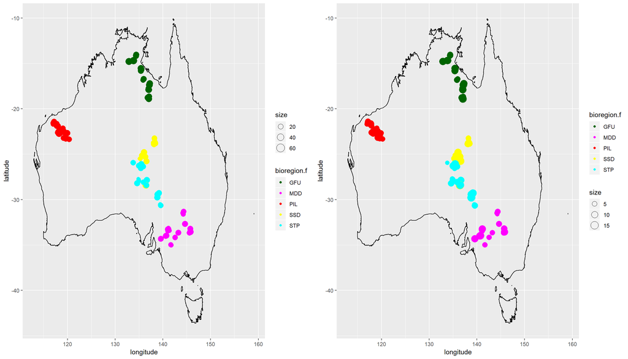

```r
# Create Species Richness Plot
Div.SR =
ggplot(data=SppBYSites.BioregTop.Div.df, aes(x=longitude, y=latitude, colour=bioregion.f, fill=bioregion.f), alpha =0.5) +
geom_point(aes_string(size=N0), pch=21) +
scale_colour_manual(values = c("darkgreen", "magenta", "red", "yellow", "cyan")) +
scale_fill_manual(values = c("darkgreen", "magenta", "red", "yellow", "cyan")) +
geom_polygon(data=fortify(aus.sp), aes(x=long, y=lat, group=group), col="black", fill=NA)

# Create Shanon Diversity Index Plot
Div.ShannonIndex =
ggplot(data=SppBYSites.BioregTop.Div.df, aes(x=longitude, y=latitude, colour=bioregion.f, fill=bioregion.f), alpha =0.5) +
geom_point(aes_string(size=N1), pch=21) +
scale_colour_manual(values = c("darkgreen", "magenta", "red", "yellow", "cyan")) +
scale_fill_manual(values = c("darkgreen", "magenta", "red", "yellow", "cyan")) +
geom_polygon(data=fortify(aus.sp), aes(x=long, y=lat, group=group), col="black", fill=NA)

# Plot the 2 graphs
grid.arrange(Div.SR, Div.ShannonIndex, ncol=2)
```

### PROPORTIONAL VEGETATION COVER (= FRACTIONAL COVER): `fractional_cover’ function

Fractional Cover (FC) is the proportional cover of green vegetation, dead vegetation and bare substrate, based on plot-based point intercept data from AusPlots (as generated by ‘get_ausplots’).

Cover fractions are assigned according to the following:

- ‘Green’ or ‘photosynthetic vegetation’ is living vascular plant cover.
- ‘Brown’ or ‘non-photosynthetic vegetation’ is either vascular plant cover scored as ‘dead’ or substrate scored as litter, coarse woody debris or cryptogam (see below) that has no other veg cover.
- ‘Bare’ or ‘bare ground’ is substrate that is rock, outcrop, gravel or bare soil with no veg cover.

A height rule is applied so that coding to green/brown/bare of the uppermost substrate/vegetation stratum hit at a given point intercept location overrides the others, that is, a dead tree overrides a living shrub beneath and vice versa; substrate coding is overridden by any vegetation cover etc. This means for each of the (usually) 1010 intercepts, there is a single coding and percentage is the number of hits assigned to each fraction, divided by the total number of PIs taken (usually 1010 but can vary) times 100.

There is an option via argument ‘ground_fractional’ to calculate fractional ground cover - the same concept applied to only grasses (hummock, tussock, other); sedge; rush; forb; fern; and vine plant growth forms. Presently, cryptogam cover is excluded and included in the non-photosynthetic fraction.

‘In canopy sky’ is excluded by default (only the substrate is considered for those hits) and applies only to regular fractional cover (as trees are excluded in the green fraction for ground fractional cover by default).

Currently, cryptogam substrate is assigned to the non-photosynthetic fraction.

Occasionally substrate type was not collected (‘NC’) or could not be assigned to one of the above categories (‘Unknwn’), in which case a percent cover will be returned under an ‘NA’ fraction if there was no veg cover above those points.

The function `fractional_cover`returns a data frame in which plots are rows, columns are fractions (bare, brown, green and NA) and values are percent cover.

In this section we will explore:

#### Latitudinal Pattern in Proportional Vegetation Cover

In this seection we will follow these steps:

- Call the `fractional_cover` function on the extracted point intercept data. This calculation may take a few minutes for all AusPlots, so for this example we will work with a random subset of 200 randomly drawn sites.
- Plot the Latitudinal Pattern in Proportional Vegetation Cover (here we use the ‘Proportion of Bare Ground’). To do this, we first enrich the dataset with additional variables including: ‘Plot’ (identifier for each Site-Visit combination), ‘bioregion.f’, ‘longitude’, and ‘latitude’.
- Fit a Quadratic Model to the data and examine its Fit, as there appears to be a humpbacked relationship in the previous plot (higher proportionof bare ground in the arid inland at mid-latitudes).

```r
# First, we call the fractional_cover function on the extracted point intercept data.
# NOTE: Calculation may take a few minutes for all AusPlots, so for this example
# we will pull out a subset of 200 randomly drawn sites to work with.
# The sets site composition will differ each time the script is run,
# as they are random subsets.

# Compute Fractional Cover using function 'fractional_cover`
# ---------------------------------------------------------
AP.200Locs.FC =
fractional_cover(AP.data$veg.PI[AP.data$veg.PI$site_location_name %in%
                                sample(AP.data$site.info$site_location_name, 200), ])
#AP.200Locs.FC = na.omit(AP.200Loc.FC)
head(AP.200Locs.FC)
```

```
##                              Plot  bare brown green  NA.
## NSABBS0002-58555 NSABBS0002-58555 17.13 42.18 40.59  0.1
## NSABBS0006-58557 NSABBS0006-58557  3.17 32.67 64.06  0.1
## NSABHC0001-53596 NSABHC0001-53596 31.26 42.24 26.51  0.0
## NSABHC0002-53597 NSABHC0002-53597  0.00  0.00 30.10 69.9
## NSABHC0004-53599 NSABHC0004-53599 26.63 36.63 36.73  0.0
## NSABHC0005-53600 NSABHC0005-53600 20.30 32.77 46.93  0.0
```

```r
# Create a site_visit variable in original dataset to relate both datasets
# ------------------------------------------------------------------------
AP.data$site.info$Plot =  paste(AP.data$site.info$site_location_name,
                                AP.data$site.info$site_location_visit_id, sep="-")
  # Enrich with: Bioregion, Latitude, and Longitude
AP.200Locs.FC  = merge(AP.200Locs.FC, AP.data$site.info, by="Plot")[,c("Plot", "bare", "brown", "green", "NA.", "bioregion.f", "longitude", "latitude")]
AP.200Locs.FC = na.omit(AP.200Locs.FC)
head(AP.200Locs.FC)
```

```
##               Plot  bare brown green  NA. bioregion.f longitude  latitude
## 1 NSABBS0002-58555 17.13 42.18 40.59  0.1         BBS  148.9925 -31.27945
## 2 NSABBS0006-58557  3.17 32.67 64.06  0.1         BBS  149.2673 -30.51027
## 3 NSABHC0001-53596 31.26 42.24 26.51  0.0         BHC  141.4338 -31.89335
## 4 NSABHC0002-53597  0.00  0.00 30.10 69.9         BHC  141.4330 -31.92703
## 5 NSABHC0004-53599 26.63 36.63 36.73  0.0         BHC  141.9481 -31.84728
## 6 NSABHC0005-53600 20.30 32.77 46.93  0.0         BHC  141.9405 -31.84496
```

```r
summary(AP.200Locs.FC)
```

```
##      Plot                bare           brown           green
##  Length:218         Min.   : 0.00   Min.   : 0.00   Min.   : 2.32
##  Class :character   1st Qu.:11.12   1st Qu.:20.82   1st Qu.:22.38
##  Mode  :character   Median :23.81   Median :29.45   Median :37.67
##                     Mean   :29.18   Mean   :30.34   Mean   :39.92
##                     3rd Qu.:46.32   3rd Qu.:38.22   3rd Qu.:52.52
##                     Max.   :89.70   Max.   :70.20   Max.   :97.92
##
##       NA.          bioregion.f    longitude        latitude
##  Min.   : 0.000   SSD    : 21   Min.   :114.7   Min.   :-37.41
##  1st Qu.: 0.000   MDD    : 18   1st Qu.:133.4   1st Qu.:-32.22
##  Median : 0.000   GUP    : 15   Median :138.1   Median :-25.84
##  Mean   : 0.574   BHC    : 14   Mean   :135.9   Mean   :-26.43
##  3rd Qu.: 0.000   GFU    : 14   3rd Qu.:141.1   3rd Qu.:-22.48
##  Max.   :69.900   MAC    : 13   Max.   :150.6   Max.   :-12.82
##                   (Other):123
```

```r
names(AP.200Locs.FC)
```

```
## [1] "Plot"        "bare"        "brown"       "green"       "NA."
## [6] "bioregion.f" "longitude"   "latitude"
```

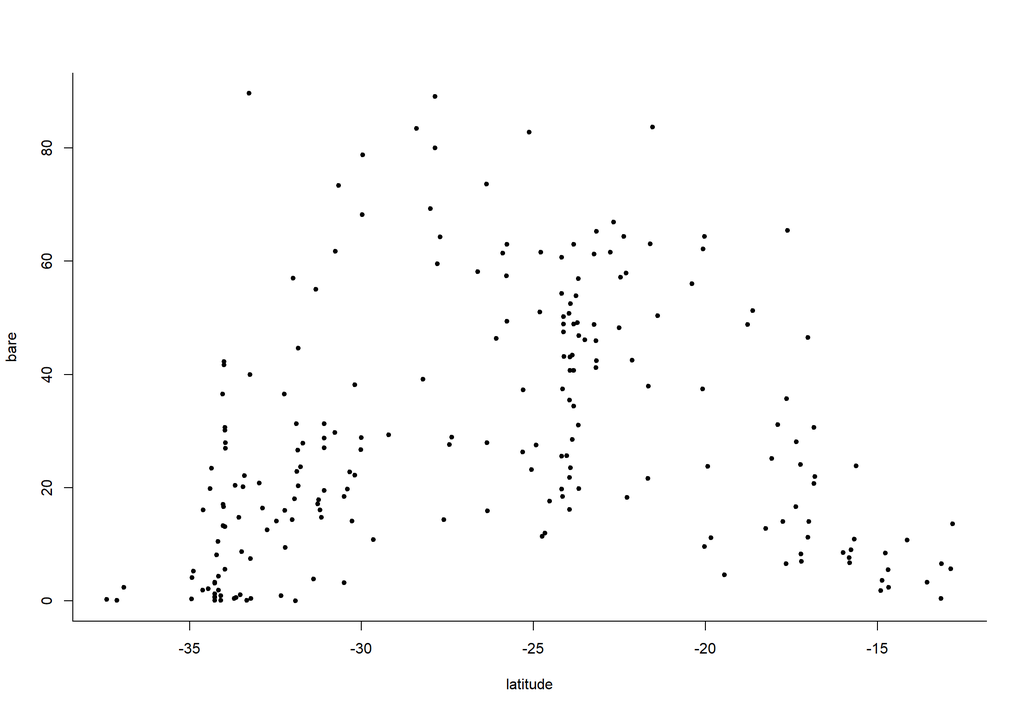

```r
# Plot out the continental relationship between Fractional Cover
# --------------------------------------------------------------
# Here we use the 'Proportion of Bare Ground' & Latitude

# Plot the relationship between Proportion of Bare Ground (with no kind of vegetation cover above) and Latitude.
par(mfrow=c(1,1))
plot(bare ~ latitude, data=AP.200Locs.FC, pch=20, bty="l")
```

```r
# Quadratic LM of Continental Relationship between Bare Ground Fractional Cover & Latitude
# ----------------------------------------------------------------------------------------

# Fit & Examine as Quadratic Linear Model the Continental Relationship between Bare Ground Fractional Cover & Latitude
AP.200Locs.FC.lm = lm(bare ~ latitude + I(latitude^2), data=AP.200Locs.FC)
summary(AP.200Locs.FC.lm)
```

```
##
## Call:
## lm(formula = bare ~ latitude + I(latitude^2), data = AP.200Locs.FC)
##
## Residuals:
##     Min      1Q  Median      3Q     Max
## -33.151 -11.782  -2.052   9.786  70.867
##
## Coefficients:
##                 Estimate Std. Error t value Pr(>|t|)
## (Intercept)   -169.58357   19.34872  -8.765 5.72e-16 ***
## latitude       -17.33567    1.58277 -10.953  < 2e-16 ***
## I(latitude^2)   -0.35088    0.03093 -11.346  < 2e-16 ***
## ---
## Signif. codes:  0 '***' 0.001 '**' 0.01 '*' 0.05 '.' 0.1 ' ' 1
##
## Residual standard error: 17.5 on 215 degrees of freedom
## Multiple R-squared:  0.3874, Adjusted R-squared:  0.3817
## F-statistic: 67.98 on 2 and 215 DF,  p-value: < 2.2e-16
```

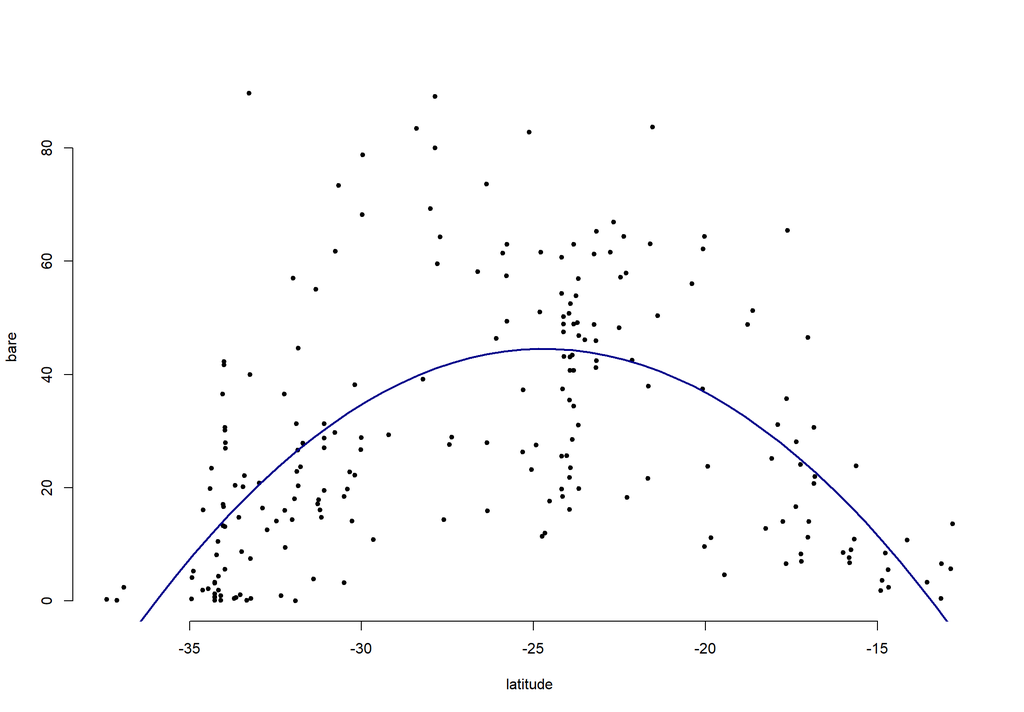

```r
# Predict values from Model Fit
pred.df = data.frame(latitude=seq(from=min(AP.200Locs.FC$latitude), to=max(AP.200Locs.FC$latitude), length.out=50))
pred.df$pred = predict(AP.200Locs.FC.lm, pred.df)

# Plot Predicted Values from Model Fit on Graph with Continental Relationship between Bare Ground Fractional Cover & Latitude
plot(bare ~ latitude, data=AP.200Locs.FC, pch=20, bty="n")
points(pred.df$latitude, pred.df$pred, type="l", lwd=2, col="darkblue")
```

### GROWTH FORM: `growth_form_table` function (for 5 most sampled bioregions)

The `growth_form_table` function in the `ausplotR` package can be used to generate occurrence matrices for NVIS plant growth forms in plots. The input for this function is a data frame of raw point intercept AusPlots data generated using the `get_ausplots` function. Three metrics can be selected to score species growth form:

- *Presence/Absence* (argument `m_kind = PA`).
- *Percent Cover*: Based on total frequency of hits (argument `m_kind = percent_cover`). This is the most useful and commonly used metric. It can be subsequently used in statistical analyses (e.g. MANOVA, Ordination, Classification, etc.)at continental scale where species turnover is too high for some methods to provide meaningful results.
- *Species Richness*: (argument `m_kind = richness`). Note that when m_kind is set to “richness” the `rowSums` of the occurrence matrix can be higher than the observed SR because sometimes the same species is recorded with different growth forms in a plot and therefore the same species can count towards the weights for multiple growth forms.

If Percent Cover is used two types of cover type can be selected:

- *Projected Foliage Cover* (*PFC*):Hits scored as ‘in canopy sky’ are removed (argument `cover_type = PFC`).
- *Opaque Canopy Cover* (*OCC*): Hits scored as ‘in canopy sky’ are retained (argument `cover_type = OCC`).

In this section we will: * Generate a Plant Growth Forms Percent Cover against Sites Matrix using the `growth_form_table` function. * Enrich this Matrix with additional information (plot -site-visit-, bioregion, longitude, and latitude). * Compute Summary Statics for each of the Growth Forms in the 5 most sampled Bioregions (slightly different to those produce by the `summary` function in the `base` package. * Cluster (Hierachical Clustering) the Sites-Visits by Plant Growth Forms Percent Cover, colouring the resulting tree branches by bioregion.

CLUSTERING RESULTS: * The first Site-Visit (NTAGFU0007-53654) is very different to the rest * The dendrogram shows clusters formed by single Bioregions at low level; however, at higher-level clusters are composed by Sites-Visits from different Bioregions.

```r
# Generate the Growth Form by Site-Visit Matrix
# =============================================
AP.BRTop5.GrowthFormBYSites = growth_form_table(AP.BioregTop5.l$veg.PI,                                                        m_kind="percent_cover", cover_type="PFC")  # % Cover
dim(AP.BRTop5.GrowthFormBYSites) # No of rows and cols in Matrix: 574 Sites x 19 Growth Forms
```

```
## [1] 209  15
```

```r
head(AP.BRTop5.GrowthFormBYSites)
```

```
##                   Chenopod  Epiphyte Fern       Forb    Fungus
## NSAMDD0001-56965 19.537815 0.0000000    0 83.1932773 0.4201681
## NSAMDD0002-56952  3.024911 0.0000000    0  0.1779359 0.0000000
## NSAMDD0003-56968 24.635036 0.0000000    0  9.3065693 0.0000000
## NSAMDD0004-56953 45.194805 0.0000000    0 31.9480519 0.0000000
## NSAMDD0005-56969 12.923077 0.0000000    0 12.0000000 0.0000000
## NSAMDD0006-56954 79.945799 0.2710027    0  3.2520325 0.0000000
##                  Hummock.grass        NC Rush Sedge      Shrub
## NSAMDD0001-56965       0.00000 2.7310924    0     0  0.0000000
## NSAMDD0002-56952      31.13879 0.0000000    0     0  1.6014235
## NSAMDD0003-56968       0.00000 0.0000000    0     0 82.8467153
## NSAMDD0004-56953       0.00000 0.0000000    0     0  5.1948052
## NSAMDD0005-56969       0.00000 0.9230769    0     0  4.0000000
## NSAMDD0006-56954       0.00000 0.0000000    0     0  0.8130081
##                  Shrub.Mallee Tree.Mallee Tree.Palm Tussock.grass Vine
## NSAMDD0001-56965    0.0000000   0.0000000  0.000000     1.8907563    0
## NSAMDD0002-56952    0.5338078  76.8683274  0.000000     0.3558719    0
## NSAMDD0003-56968    0.0000000   0.3649635  1.094891     0.0000000    0
## NSAMDD0004-56953    0.0000000   0.0000000 28.831169     1.0389610    0
## NSAMDD0005-56969    0.0000000  76.6153846  0.000000     0.3076923    0
## NSAMDD0006-56954    0.0000000   0.0000000 32.249322     0.5420054    0
```

```r
# Enrich DF
# =========

# Add Plot (Site-Vist)
# --------------------
AP.BRTop5.GrowthFormBYSites$Plot = rownames(AP.BRTop5.GrowthFormBYSites)

# Add: Bioregion, Longitude, Latitude
# -----------------------------------
# Both DF have different number of rows (again!)
dim(AP.BRTop5.GrowthFormBYSites)
```

```
## [1] 209  16
```

```r
dim(AP.BioregTop5.l$site.info)
```

```
## [1] 213  43
```

```r
# Enrich with: Bioregion, Latitude, and Longitude
AP.BRTop5.GrowthFormBYSites  = merge(AP.BRTop5.GrowthFormBYSites, AP.BioregTop5.l$site.info, by="Plot")[,c(names(AP.BRTop5.GrowthFormBYSites),
                                                                                            "bioregion.f", "longitude", "latitude")]
AP.BRTop5.GrowthFormBYSites = na.omit(AP.BRTop5.GrowthFormBYSites)
#head(AP.BRTop5.GrowthFormBYSites)
summary(AP.BRTop5.GrowthFormBYSites)
```

```
##     Chenopod         Epiphyte           Fern              Forb
##  Min.   :  0.00   Min.   :0.0000   Min.   :0.00000   Min.   : 0.000
##  1st Qu.:  0.00   1st Qu.:0.0000   1st Qu.:0.00000   1st Qu.: 1.480
##  Median :  1.25   Median :0.0000   Median :0.00000   Median : 6.195
##  Mean   : 14.04   Mean   :0.0518   Mean   :0.08369   Mean   :14.525
##  3rd Qu.: 20.99   3rd Qu.:0.0000   3rd Qu.:0.00000   3rd Qu.:19.333
##  Max.   :100.00   Max.   :2.9748   Max.   :3.22581   Max.   :94.268
##      Fungus        Hummock.grass          NC               Rush
##  Min.   :0.00000   Min.   :  0.00   Min.   :0.00000   Min.   :0.000000
##  1st Qu.:0.00000   1st Qu.:  0.00   1st Qu.:0.00000   1st Qu.:0.000000
##  Median :0.00000   Median :  0.00   Median :0.00000   Median :0.000000
##  Mean   :0.00201   Mean   : 16.24   Mean   :0.06417   Mean   :0.004679
##  3rd Qu.:0.00000   3rd Qu.: 22.42   3rd Qu.:0.00000   3rd Qu.:0.000000
##  Max.   :0.42017   Max.   :183.86   Max.   :2.80374   Max.   :0.764331
##      Sedge             Shrub         Shrub.Mallee      Tree.Mallee
##  Min.   : 0.0000   Min.   : 0.000   Min.   : 0.0000   Min.   : 0.000
##  1st Qu.: 0.0000   1st Qu.: 2.488   1st Qu.: 0.0000   1st Qu.: 0.000
##  Median : 0.0000   Median : 9.091   Median : 0.0000   Median : 0.000
##  Mean   : 0.7157   Mean   :19.164   Mean   : 0.6826   Mean   : 6.805
##  3rd Qu.: 0.0000   3rd Qu.:28.101   3rd Qu.: 0.0000   3rd Qu.: 0.000
##  Max.   :21.6561   Max.   :91.042   Max.   :37.7863   Max.   :91.979
##    Tree.Palm       Tussock.grass         Vine             Plot
##  Min.   : 0.0000   Min.   : 0.000   Min.   : 0.0000   Length:209
##  1st Qu.: 0.0000   1st Qu.: 2.262   1st Qu.: 0.0000   Class :character
##  Median : 0.3745   Median :16.425   Median : 0.0000   Mode  :character
##  Mean   :12.3747   Mean   :27.278   Mean   : 0.3843
##  3rd Qu.:15.1351   3rd Qu.:45.905   3rd Qu.: 0.0000
##  Max.   :99.1747   Max.   :99.051   Max.   :26.1456
##  bioregion.f   longitude        latitude
##  GFU:41      Min.   :117.0   Min.   :-35.00
##  MDD:49      1st Qu.:134.9   1st Qu.:-29.76
##  PIL:35      Median :136.7   Median :-25.11
##  SSD:46      Mean   :134.8   Mean   :-25.35
##  STP:38      3rd Qu.:139.2   3rd Qu.:-21.87
##              Max.   :145.8   Max.   :-14.05
```

```r
names(AP.BRTop5.GrowthFormBYSites)
```

```
##  [1] "Chenopod"      "Epiphyte"      "Fern"          "Forb"
##  [5] "Fungus"        "Hummock.grass" "NC"            "Rush"
##  [9] "Sedge"         "Shrub"         "Shrub.Mallee"  "Tree.Mallee"
## [13] "Tree.Palm"     "Tussock.grass" "Vine"          "Plot"
## [17] "bioregion.f"   "longitude"     "latitude"
```

```r
# Summary Statistics for Each Growth Form
# =======================================
AP.BRTop5.GFBYSites.DescStats = data.frame(
  Min = apply(AP.BRTop5.GrowthFormBYSites[,1: (dim(AP.BRTop5.GrowthFormBYSites)[2]-4)], 2,               min), # Minimum
  Med = apply(AP.BRTop5.GrowthFormBYSites[,1: (dim(AP.BRTop5.GrowthFormBYSites)[2]-4)], 2,               median), # Median
  Max = apply(AP.BRTop5.GrowthFormBYSites[,1: (dim(AP.BRTop5.GrowthFormBYSites)[2]-4)], 2,               max), # Maximum
  Mean = apply(AP.BRTop5.GrowthFormBYSites[,1: (dim(AP.BRTop5.GrowthFormBYSites)[2]-4)], 2,                mean), # Mean
  SD = apply(AP.BRTop5.GrowthFormBYSites[,1: (dim(AP.BRTop5.GrowthFormBYSites)[2]-4)], 2,               sd) # Standard Deviation
  )
AP.BRTop5.GFBYSites.DescStats = round(AP.BRTop5.GFBYSites.DescStats, 2)
AP.BRTop5.GFBYSites.DescStats
```

```
##               Min   Med    Max  Mean    SD
## Chenopod        0  1.25 100.00 14.04 22.35
## Epiphyte        0  0.00   2.97  0.05  0.28
## Fern            0  0.00   3.23  0.08  0.39
## Forb            0  6.19  94.27 14.53 18.96
## Fungus          0  0.00   0.42  0.00  0.03
## Hummock.grass   0  0.00 183.86 16.24 29.09
## NC              0  0.00   2.80  0.06  0.33
## Rush            0  0.00   0.76  0.00  0.05
## Sedge           0  0.00  21.66  0.72  2.83
## Shrub           0  9.09  91.04 19.16 22.43
## Shrub.Mallee    0  0.00  37.79  0.68  4.04
## Tree.Mallee     0  0.00  91.98  6.81 17.62
## Tree.Palm       0  0.37  99.17 12.37 21.88
## Tussock.grass   0 16.43  99.05 27.28 27.82
## Vine            0  0.00  26.15  0.38  2.06
```

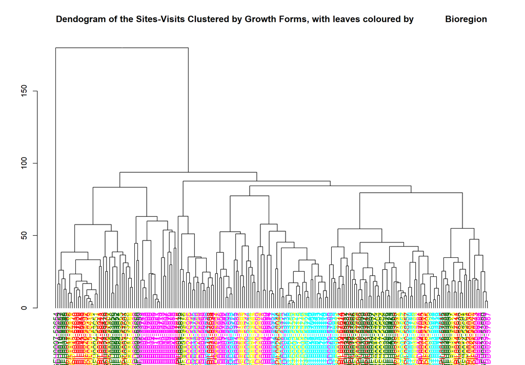

```r
# Create and Plot a Dendogram of the Sites-Visits Clustered by Growth Forms
# =========================================================================

# Add rownames to be used as Leaves Names
rownames(AP.BRTop5.GrowthFormBYSites) = AP.BRTop5.GrowthFormBYSites$Plot

# Create Dendogram
AP.BRTop5.GFBYSites.dend = as.dendrogram(hclust(dist(AP.BRTop5.GrowthFormBYSites[,1: (dim(AP.BRTop5.GrowthFormBYSites)[2]-4)]), "average"))

# Color the Leaves by Bioregion
# NOTE: The most sampled bioregions might change as new data is added. If so, bioregions codes bellow should be revised.
# Here the codes correspond to: MDD (Murry Darling Depression), SSD (Simpson
# Strzelecki Dunefields), GFU (Gulf Fall and Uplands), STP (Stony Plains),
# PIL (Pilbara)
AP.BRTop5.GrowthFormBYSites$bioregion.col.f = AP.BRTop5.GrowthFormBYSites$bioregion.f
levels(AP.BRTop5.GrowthFormBYSites$bioregion.col.f)[levels(AP.BRTop5.GrowthFormBYSites$bioregion.col.f) == "GFU"] = "darkgreen"
levels(AP.BRTop5.GrowthFormBYSites$bioregion.col.f)[levels(AP.BRTop5.GrowthFormBYSites$bioregion.col.f) == "MDD"] = "magenta"
levels(AP.BRTop5.GrowthFormBYSites$bioregion.col.f)[levels(AP.BRTop5.GrowthFormBYSites$bioregion.col.f) == "PIL"] = "red"
levels(AP.BRTop5.GrowthFormBYSites$bioregion.col.f)[levels(AP.BRTop5.GrowthFormBYSites$bioregion.col.f) == "SSD"] = "yellow"
levels(AP.BRTop5.GrowthFormBYSites$bioregion.col.f)[levels(AP.BRTop5.GrowthFormBYSites$bioregion.col.f) == "STP"] = "cyan"
dend.colors = as.character(AP.BRTop5.GrowthFormBYSites$bioregion.col.f)
#dend.colors
dend.colors = dend.colors[order.dendrogram(AP.BRTop5.GFBYSites.dend)]
#dend.colors
labels_colors(AP.BRTop5.GFBYSites.dend) = dend.colors
# Plot Dendrogram
plot(AP.BRTop5.GFBYSites.dend,
     main="Dendogram of the Sites-Visits Clustered by Growth Forms, with leaves coloured by            Bioregion")
```

### BASAL AREA (OR NUMBER OF BASAL WEDGE HITS): `basal_area` function (for 5 most sampled bioregions).

The `basal_area` function calculates the Basal Area (or Number of Basal Wedge Hits) for each plot, using the raw basal wedge data returned by the `get_ausplots` funcion also in the `ausplotsR` package. This function returns a data frame with rows representing Plots (or species by plots) and a single column containning the Basal Area (m2/ha) or Hit Scores.

In this section we will:

- Compute the Basal Area for each plot (m2/ha) using the `basal_area` function.
- Enrich the data frame containing the Basal Area data with additional information (i.e. plot -Site-Visit-, bioregion, longitude, and latitude).
- Display Basal Areas on map of Australia (with Dots size proportional to Basal Area).
- Boxplot of Basal Areas by Bioregion.

```r
# Calculate Basal Area
# ====================
AP.BioregTop5.BA = basal_area(AP.BioregTop5.l$veg.basal)
summary(AP.BioregTop5.BA)
```

```
##  site_unique        basal_area_m2_ha
##  Length:99          Min.   : 0.2857
##  Class :character   1st Qu.: 1.4333
##  Mode  :character   Median : 3.6611
##                     Mean   : 4.4389
##                     3rd Qu.: 5.3542
##                     Max.   :15.8000
```

```r
head(AP.BioregTop5.BA)
```

```
##        site_unique basal_area_m2_ha
## 1 NSAMDD0002-56952         4.583333
## 2 NSAMDD0004-56953         4.805556
## 3 NSAMDD0005-56969         5.538889
## 4 NSAMDD0006-56954         4.077778
## 5 NSAMDD0007-56970         4.205556
## 6 NSAMDD0009-56971        14.694444
```

```r
# Enrich DF
# =========
# Preparation
colnames(AP.BioregTop5.BA)
```

```
## [1] "site_unique"      "basal_area_m2_ha"
```

```r
colnames(AP.BioregTop5.BA)[1] = "Plot"  # Change the name to be able to Merge DFs
summary(AP.BioregTop5.BA)
```

```
##      Plot           basal_area_m2_ha
##  Length:99          Min.   : 0.2857
##  Class :character   1st Qu.: 1.4333
##  Mode  :character   Median : 3.6611
##                     Mean   : 4.4389
##                     3rd Qu.: 5.3542
##                     Max.   :15.8000
```

```r
head(AP.BioregTop5.BA)
```

```
##               Plot basal_area_m2_ha
## 1 NSAMDD0002-56952         4.583333
## 2 NSAMDD0004-56953         4.805556
## 3 NSAMDD0005-56969         5.538889
## 4 NSAMDD0006-56954         4.077778
## 5 NSAMDD0007-56970         4.205556
## 6 NSAMDD0009-56971        14.694444
```

```r
# Add: Bioregion, Longitude, Latitude
# ----------------------------------
# Both DF have different number of rows (again!)
dim(AP.BioregTop5.BA)
```

```
## [1] 99  2
```

```r
dim(AP.BioregTop5.l$site.info)
```

```
## [1] 213  43
```

```r
# Enrich with: Bioregion, Latitude, and Longitude
AP.BioregTop5.BA  = merge(AP.BioregTop5.BA, AP.BioregTop5.l$site.info, by="Plot")[,c(names(AP.BioregTop5.BA),
                                                                                            "bioregion.f", "longitude", "latitude")]
AP.BioregTop5.BA = na.omit(AP.BioregTop5.BA)
head(AP.BioregTop5.BA)
```

```
##               Plot basal_area_m2_ha bioregion.f longitude  latitude
## 1 NSAMDD0002-56952         4.583333         MDD  142.6026 -34.20482
## 2 NSAMDD0004-56953         4.805556         MDD  142.5594 -34.16537
## 3 NSAMDD0005-56969         5.538889         MDD  143.2039 -33.65619
## 4 NSAMDD0006-56954         4.077778         MDD  143.1665 -33.66432
## 5 NSAMDD0007-56970         4.205556         MDD  141.1608 -33.37998
## 6 NSAMDD0009-56971        14.694444         MDD  141.0655 -33.44049
```

```r
summary(AP.BioregTop5.BA)
```

```
##      Plot           basal_area_m2_ha  bioregion.f   longitude
##  Length:99          Min.   : 0.2857   GFU:34      Min.   :117.1
##  Class :character   1st Qu.: 1.4333   MDD:27      1st Qu.:126.6
##  Mode  :character   Median : 3.6611   PIL:25      Median :136.0
##                     Mean   : 4.4389   SSD: 9      Mean   :133.5
##                     3rd Qu.: 5.3542   STP: 4      3rd Qu.:140.6
##                     Max.   :15.8000               Max.   :145.8
##     latitude
##  Min.   :-35.00
##  1st Qu.:-31.55
##  Median :-22.62
##  Mean   :-23.65
##  3rd Qu.:-17.82
##  Max.   :-14.05
```

```r
names(AP.BioregTop5.BA)
```

```
## [1] "Plot"             "basal_area_m2_ha" "bioregion.f"
## [4] "longitude"        "latitude"
```

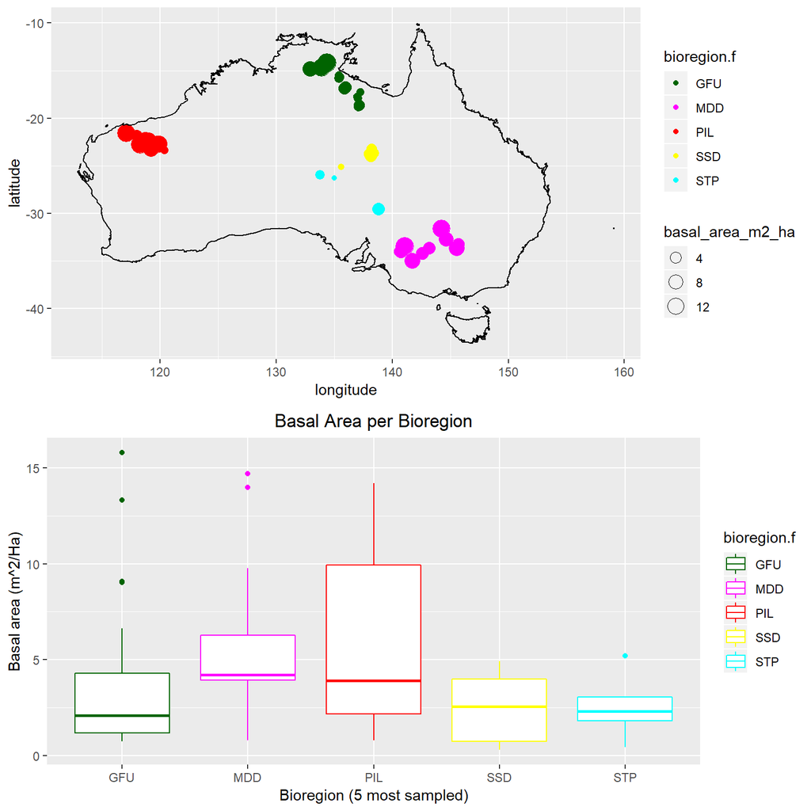

```r
# Graphical Visualisation
# =======================

# Map with circle size the Basal Area (m2/ha)
# -------------------------------------------
AP.BioregTop5.BA.p1 =
ggplot(data=AP.BioregTop5.BA, aes(x=longitude, y=latitude, colour=bioregion.f, fill=bioregion.f), alpha =0.5) +
geom_point(aes(size=basal_area_m2_ha), pch=21) +
scale_colour_manual(values = c("darkgreen", "magenta", "red", "yellow", "cyan")) +
scale_fill_manual(values = c("darkgreen", "magenta", "red", "yellow", "cyan")) +
geom_polygon(data=fortify(aus.sp), aes(x=long, y=lat, group=group), col="black", fill=NA)

# Boxplot
# -------
AP.BioregTop5.BA.p2 =
ggplot(AP.BioregTop5.BA, aes(x=bioregion.f, y=basal_area_m2_ha, color=bioregion.f)) +
geom_boxplot() +
scale_colour_manual(values = c("darkgreen", "magenta", "red", "yellow", "cyan")) +
scale_fill_manual(name="Bioregions (Top 5)", values = c("darkgreen", "magenta", "red", "yellow", "cyan")) +
labs(title="Basal Area per Bioregion",x="Bioregion (5 most sampled)", y = "Basal area (m^2/Ha)") +
theme(plot.title = element_text(hjust = 0.5))

# Plot both graphs
# ----------------
grid.arrange(AP.BioregTop5.BA.p1, AP.BioregTop5.BA.p2, nrow=2)
```

```r
#grid.arrange(AP.BioregTop5.BA.p1, AP.BioregTop5.BA.p2, ncol=2)
```